# Spatial Analysis with R: Exercise 3a: Geoprocessing, Overlays, and Distance Surface

### ### Buffer Towers and Compute Percent Intersection

# 6. Create a one-mile buffer around each cell tower to represent the area that can receive a strong  
# signal (although not really, this is just an example). Merge them together if needed to get a  
# single polygon representing strong signal coverage.

One mile is 1609 meters.  
The *rgeos* package has many geoprocessing functions.

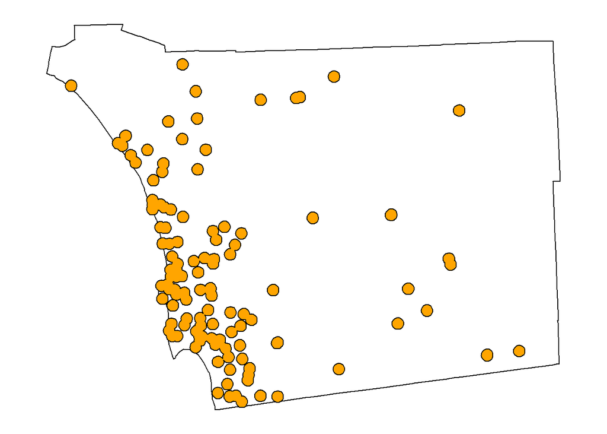

```r
library(rgeos, quietly = TRUE)
sdtowers_buff01mi <- gBuffer(sdtowers, width=1609, byid=F)
plot(sandiego_alb, asp=1)
plot(sdtowers_buff01mi, add=TRUE, col="orange")
```

Note we set `byid=FALSE` so that R will create a single merged buffer for all of the tower locations.

# 7. Next, find the proportion of San Diego County (by area) that lies within 1 mile of a cell tower.

There’s a function in the *rgeos* package that returns the area of features in a SpatialPolygons object.

```r
#Area of the county:
gArea(sandiego_alb)
```

```
## [1] 11032256666
```

```r
#Area of the cell tower buffers:
gArea(sdtowers_buff01mi)
```

```
## [1] 791126700
```

```r
#Proportion of county
round(gArea(sdtowers_buff01mi) / gArea(sandiego_alb), 3)
```

```
## [1] 0.072
```

### ### Repeat with Larger Buffers

# 8. Repeat the previous two steps for buffer distances 5 mi and 10 mi. Plot the buffered area on top of  
# the county boundary for a reality-check.

Make sure you clip the buffered area to the county boundary to avoid over estimating the area

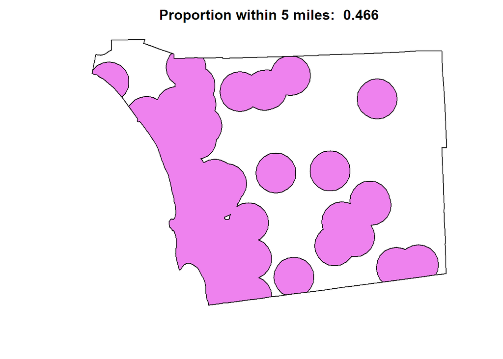

```r
sdtowers_buff5mi <- gBuffer(sdtowers, width=1609*5, byid=F)
sdtowers_buff5mi_clipped <- gIntersection(sdtowers_buff5mi, sandiego_alb)
prop5mi <- round(gArea(sdtowers_buff5mi_clipped) / gArea(sandiego_alb), 3)
plot(sandiego_alb, asp=1, main=paste("Proportion within 5 miles: ", prop5mi))
plot(sdtowers_buff5mi_clipped, add=TRUE, col="violet")
plot(sandiego_alb, add=TRUE)
```

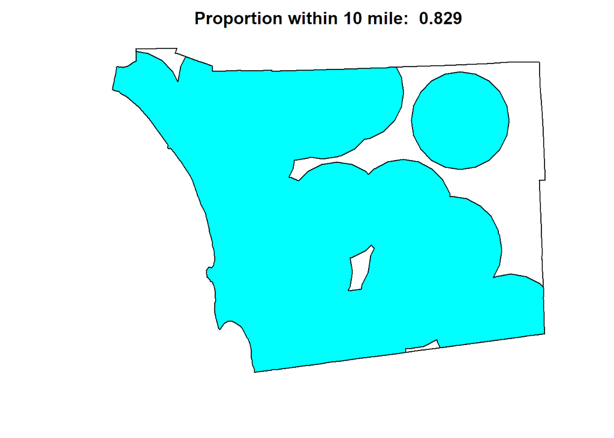

```r
sdtowers_buff10mi <- gBuffer(sdtowers, width=1609*10, byid=F)
sdtowers_buff10mi_clipped <- gIntersection(sdtowers_buff10mi, sandiego_alb)
prop10mi <- round(gArea(sdtowers_buff10mi_clipped) / gArea(sandiego_alb), 3)
plot(sandiego_alb, asp=1, main=paste("Proportion within 10 mile: ", prop10mi))
plot(sdtowers_buff10mi_clipped, add=TRUE, col="cyan")
plot(sandiego_alb, add=TRUE)
```

### ### Create a Distance Surface

# A distance surface is a raster layer where the value of each pixel is the distance to the  
# nearest cell tower. The *raster* package has a strong set of functions for working with raster  
# data.

# The first step in this analysis is to create a raster surface that covers the extent of the  
# county. We don’t need to assign values to the pixels just yet, but we need to make sure the extent  
# covers the county completely, and the resolution is sufficiently fine for our desired level of  
# precision.

# 9. Create a raster the covers your county. Make the spatial resolution 1/4 mile.

- The `raster()` is a multi-purpose function for creating rasters either from scratch or by importing a file from disk.
- To define a raster, you need to know at least two of the following three parameters (the third one can always be computed from the other two)
  - the extent (i.e., x and y coordinates of the corners)
  - number of rows and colums
  - resolution (pixel size)
- Read the help page for `raster()` and look for an option that allows you to create a raster based on the extent of another Spatial object.

```r
library(raster, quietly=TRUE)
quarter_mi <- 1609 / 4  ## quarter mile in meters
sd_rast <- raster(sandiego_alb, resolution=c(quarter_mi,quarter_mi))
sd_rast
```

```
## class       : RasterLayer
## dimensions  : 266, 354, 94164  (nrow, ncol, ncell)
## resolution  : 402.25, 402.25  (x, y)
## extent      : 223778.4, 366174.9, -604647.9, -497649.4  (xmin, xmax, ymin, ymax)
## coord. ref. : +init=epsg:3310 +proj=aea +lat_1=34 +lat_2=40.5 +lat_0=0 +lon_0=-120 +x_0=0 +y_0=-4000000 +datum=NAD83 +units=m +no_defs +ellps=GRS80 +towgs84=0,0,0
```

# 10. Rasterize the tower locations in your county.

- Rasterize means convert from a vector format to a raster format. You can rasterize any kind of vector feature - points, lines, or polygons.
- When you rasterize vector features, you need to decide what the values of the cells where the vector object lies should be.

```r
sdtowers_rast <- rasterize(sdtowers, sd_rast, field=1)
table(getValues(sdtowers_rast))
```

```
##
##   1
## 118
```

# 11. Create the distance surface and plot it.

Use the `distance()` function

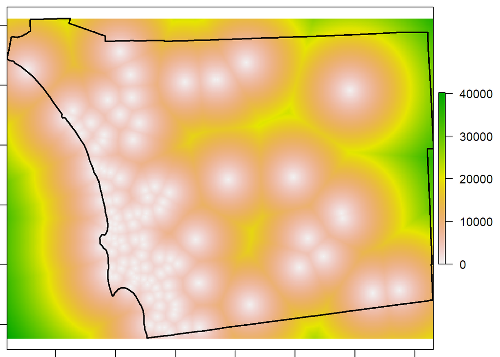

```r
sdtowers_dist <- distance(sdtowers_rast)
plot(sdtowers_dist)
plot(sandiego_alb, add=T, lwd=2)
```

Note the raster package also has a function `distanceFromPoints()`, which combines the rasterize and distance calculations in one step.

# 12. Save the objects you created in this exercise to disk.

```r
save(list=c("ca_counties", "celltwrSP_alb", "sandiego_alb", "sd_rast", "sdtowers", "sdtowers_buff10mi_clipped", "sdtowers_buff01mi", "sdtowers_buff5mi_clipped" , "sdtowers_dist", "sdtowers_rast"), file="exercise3a_outputs.RData")
```

### ### Bonus Questions

# 13. Using the distance raster created above, compute the average distance to a cell tower for the  
# entire county.

- The distance surface needs to be masked to the county boundary so you only count pixels within the county.
- Look at the `getValues()` function.

First we have to clip our distance surface to the county boundary. We can do this with the mask() function from the raster package.

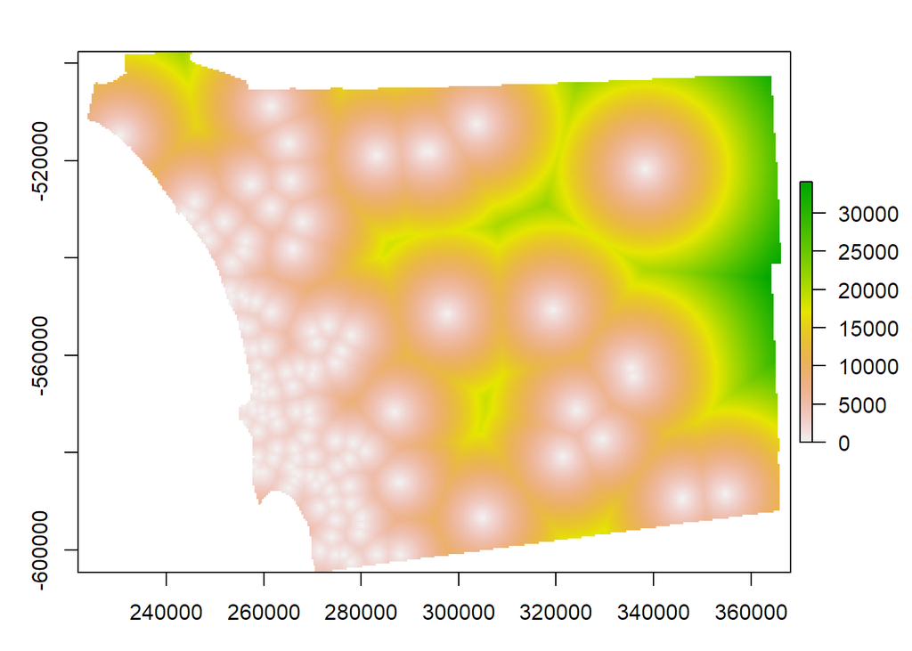

```r
sdtowers_dist_clipped <- mask(sdtowers_dist, sandiego_alb)
plot(sdtowers_dist_clipped)
```

The pixel values are the distance to the nearest cell tower in meters. So all we need to do is grab their values and compute the mean. Fortunately the `mean()` function has an argument to ignore NA values.

```r
mean(getValues(sdtowers_dist_clipped), na.rm=TRUE)
```

```
## [1] 9649.171
```

# 14. Using buffers, compute the proportion of **every** county in California that lies within 5 mile of  
# a cell tower. Present these in a table ordered by the proportion.

Use a loop.

```r
## Create an empty numeric vector to save the results
county_prp <- numeric()

## Loop through the counties SPDF
for (i in 1:nrow(ca_counties)) {

  ## Grab the current county boundary
  county_boundary <- ca_counties[i, ]

  ## Copy the projection of the cell towers to this county boundary so the overlay function works
  ## (we know they are both CA Albers, but the over() function require them to match exactly)
  county_boundary@proj4string <- celltwrSP_alb@proj4string

  ## Use the over() function to find out which cell towers fall within this count
  ## Note our use of the geometry() functino to turn the SpatialPolygonsDataFrame
  ## object into a SpatialPolygons object
  tower_in_cnty <- over(celltwrSP_alb, geometry(county_boundary))
  towers_sp <- celltwrSP_alb[which(tower_in_cnty==1), ]

  ## Create a five-mile buffer of all the towers, and clip it to the county boundary
  towers_buff5mi <- gBuffer(towers_sp, width=1609*5, byid=F)
  towers_buff5mi_clipped <- gIntersection(towers_buff5mi, county_boundary)

  ## Compute the proportion of the county area that lies within a 5 mile radius of a tower
  prop5mi <- round(gArea(towers_buff5mi_clipped) / gArea(county_boundary), 3)

  ## Add the proportion to the end of the county_prp vector
  county_prp <- c(county_prp, prop5mi)

  ## Print a message to the console so the user knows things are working
  cat(as.character(ca_counties@data[i, "CountyNAME"]), prop5mi, "\n")

  ## Plotting is another way you can tell your code is working
  #plot(county_boundary, asp=1)
  #plot(towers_buff5mi_clipped, add=TRUE, col="cyan")
  #plot(towers_sp, add=TRUE, col="red")
}
```

```
## Stanislaus County 0.462
## San Francisco County 0.993
## Amador County 0.547
## San Bernardino County 0.13
## Sierra County 0.08
## Siskiyou County 0.139
## Plumas County 0.115
## San Luis Obispo County 0.239
## Modoc County 0.12
## Colusa County 0.326
## Contra Costa County 0.849
## Ventura County 0.423
## Orange County 0.613
## Yolo County 0.465
## Fresno County 0.37
## Lake County 0.186
## Nevada County 0.389
## Los Angeles County 0.43
## Monterey County 0.33
## Sutter County 0.642
## Kern County 0.378
## San Diego County 0.466
## Mono County 0.185
## San Benito County 0.266
## Imperial County 0.24
## Lassen County 0.143
## Placer County 0.428
## Shasta County 0.194
## Riverside County 0.211
## Sacramento County 0.75
## Santa Barbara County 0.401
## San Mateo County 0.751
## Santa Cruz County 0.731
## Santa Clara County 0.565
## Solano County 0.616
## San Joaquin County 0.845
## Alameda County 0.533
## Tuolumne County 0.266
## Glenn County 0.311
## Humboldt County 0.236
## Merced County 0.455
## Tehama County 0.168
## Mendocino County 0.345
## Sonoma County 0.473
## Mariposa County 0.305
## Tulare County 0.198
## Marin County 0.561
## Trinity County 0.112
## Alpine County 0.271
## Kings County 0.432
## Inyo County 0.064
## Calaveras County 0.365
## Madera County 0.391
## El Dorado County 0.276
## Butte County 0.355
## Napa County 0.386
## Yuba County 0.32
## Del Norte County 0.326
```

```r
## Prepare a data frame with the county name and proportion within 5mi of a tower.
cnty_prp5mi_df <- data.frame(county=as.character(ca_counties@data$CountyNAME), prp=county_prp)

## Show the table ordered by proportion covered
idx <- order(cnty_prp5mi_df$prp, decreasing = TRUE)
cnty_prp5mi_df[idx,]
```

```
##                    county   prp
## 2    San Francisco County 0.993
## 11    Contra Costa County 0.849
## 36     San Joaquin County 0.845
## 32       San Mateo County 0.751
## 30      Sacramento County 0.750
## 33      Santa Cruz County 0.731
## 20          Sutter County 0.642
## 35          Solano County 0.616
## 13          Orange County 0.613
## 34     Santa Clara County 0.565
## 47           Marin County 0.561
## 3           Amador County 0.547
## 37         Alameda County 0.533
## 44          Sonoma County 0.473
```

[output cut: 44 more lines]